# Bat Echolocation

Capstone project: BIDA 302

Author

Husanpreet Kaur

Published

November 26, 2025

## Introduction

Echolocation call data for 4 species of Vancouver Island bats (https://bcbats.ca/bat-basics/bat-species-in-bc/). Call data comprises 30 unique records for 4 echolocation call parameters for each of the bat species. Call data was recorded using an ultrasonic bat detector (Anabat; Titley Scientific https://www.titley-scientific.com/) with call parameters downloaded and extracted using AnaLook.

For this project, explore the data using the inspiration provided by the penguin analysis (below).

### Data source

Variables:

**Species**

EPFU - Eptesicus fuscus; Big Brown Bat

LACI - Lasiurus cinereus; Hoary Bat

MYLU - Myotis lucifugus; Little Brown Bat

MYVO - Myotis volans; Long-legged Myotis

**Filename** - Unique ID for each bat call

*Echolocation Call Paramters:*

**Time_Btw_Calls** - Time between calls (milliseconds)

**Duration** - Duration of the body of call (milliseconds)

**Frequency** - Characteristic frequency (kHz)

**Slope** - Characteristic slope

Source: Dr. Joanna Burgar; https://github.com/joburgar/Bat_Data

### Additional Inspiration

The R package {palmerpenguins} reference page has some tabulations and visualizations that may provide some inspiration:

- https://allisonhorst.github.io/palmerpenguins/
- in particular, the “Get started” and “Articles” have both the visualizations and the code used to create those visualizations.

## Other resources

**Statistical analysis of bat calls**

David W. Armitage and Holly K. Ober, A comparison of supervised learning techniques in the classification of bat echolocation calls, *Ecological Infomatics*, 2010, 5, 465:473.

Xing Chen, Jun Zhaob, Yan-hua Chen, Wei Zhoub, and Alice C.Hughes, [Automatic standardized processing and identification of tropical bat calls using deep learning approaches](https://www.sciencedirect.com/science/article/pii/S0006320719308961), *Biological Conservation*, January 2020, Vol.241, doi: 10.1016/j.biocon.2019.108269

Oisin MacAodha, Rory Gibb, Kate E. Barlow, et al., [Bat detective—Deep learning tools for bat acoustic signal detection](https://journals.plos.org/ploscompbiol/article?id=10.1371/journal.pcbi.1005995), *PLOS Computational Biology*, 2018-03-08, doi: 10.1371/journal.pcbi.1005995

Keisuke Masuda, Takanori Matsui, Dai Fukui, et al., [Bat species classification by echolocation call using a machine learning system](https://www.jstage.jst.go.jp/article/mammalianscience/57/1/57_19/_article), *Honyurui Kagaku (Mammalian Science)*, Volume 57 (2017) Issue 1. doi: 10.11238/mammalianscience.57.19

Peter Ommundsen,Cori Lausen, Laura Matthias, [First Acoustic Records of the Brazilian Free-Tailed Bat (Tadarida brasiliensis) In British Columbia](https://www.researchgate.net/publication/319424456_First_Acoustic_Records_of_the_Brazilian_Free-Tailed_Bat_Tadarida_brasiliensis_In_British_Columbia), September 2017, *Northwestern Naturalist*, 98(2):132-136, DOI: 10.1898/NWN16-24.1

Veronica Zamora-Gutierrez, Celia Lopez-Gonzalez, M. Cristina MacSwiney Gonzalez, et al., [Acoustic identification of Mexican bats based on taxonomic and ecological constraints on call design](https://besjournals.onlinelibrary.wiley.com/doi/pdf/10.1111/2041-210X.12556), *Methods in Ecology and Evolution* 2016, 7, 1082–1091. doi: 10.1111/2041-210X.12556

**Other bat communication**

Jason Daley, [Researchers “Translate” Bat Talk. Turns Out, They Argue—A Lot](https://getpocket.com/explore/item/researchers-translate-bat-talk-turns-out-they-argue-a-lot), *Smithsonian Magazine*, 2016-12-22.

# **Bat Echolocation Capstone Project**

## **Introduction**

- Time_Btw_Calls (ms)
- Duration (ms)
- Frequency (kHz)
- Slope

In this project, we will import, tidy, visualize, and analyze the bat call data following an approach inspired by the Palmer Penguins dataset.

## **Data import**

```r
#import necessary libraries for this project
library(tidyverse)
library(janitor)
library(knitr)
```

```r
#import  data
bat_data <- read_csv("Bat_Call_Data.csv")
##View the first few rows of th impoteed data
head(bat_data)
```

```
# A tibble: 6 × 6
  Species Filename     Time_Btw_Calls Frequency Duration Slope
  <chr>   <chr>                 <dbl>     <dbl>    <dbl> <dbl>
1 EPFU    B6212118.46#            170        26        6    32
2 EPFU    B7122143.02#            218        26        7    24
3 EPFU    B7122201.58#            174        27        5    23
4 EPFU    B7122203.47#            275        26        7    29
5 EPFU    B7122231.29#            213        26        5    38
6 EPFU    B7192030.55#            145        27        3    38
```

```r
#inspect structure of imported data
glimpse(bat_data)
```

```
Rows: 120
Columns: 6
$ Species        <chr> "EPFU", "EPFU", "EPFU", "EPFU", "EPFU", "EPFU", "EPFU",…
$ Filename       <chr> "B6212118.46#", "B7122143.02#", "B7122201.58#", "B71222…
$ Time_Btw_Calls <dbl> 170, 218, 174, 275, 213, 145, 181, 130, 128, 146, 398, …
$ Frequency      <dbl> 26, 26, 27, 26, 26, 27, 25, 28, 29, 25, 26, 29, 28, 26,…
$ Duration       <dbl> 6, 7, 5, 7, 5, 3, 3, 3, 4, 5, 7, 3, 4, 7, 6, 5, 5, 5, 5…
$ Slope          <dbl> 32, 24, 23, 29, 38, 38, 48, 55, 28, 44, 22, 42, 42, 18,…
```

### **Defining variable types**

```r
#defining the variable types from the dataset
bat_data <- bat_data %>%
  clean_names() %>%
  mutate(
    species = as.factor(species),
    filename = as.character(filename),
    time_btw_calls = as.numeric(time_btw_calls),
    duration = as.numeric(duration),
    frequency = as.numeric(frequency),
    slope = as.numeric(slope)
  )
# Confirm the changes made to variable types
glimpse(bat_data)
```

```
Rows: 120
Columns: 6
$ species        <fct> EPFU, EPFU, EPFU, EPFU, EPFU, EPFU, EPFU, EPFU, EPFU, E…
$ filename       <chr> "B6212118.46#", "B7122143.02#", "B7122201.58#", "B71222…
$ time_btw_calls <dbl> 170, 218, 174, 275, 213, 145, 181, 130, 128, 146, 398, …
$ frequency      <dbl> 26, 26, 27, 26, 26, 27, 25, 28, 29, 25, 26, 29, 28, 26,…
$ duration       <dbl> 6, 7, 5, 7, 5, 3, 3, 3, 4, 5, 7, 3, 4, 7, 6, 5, 5, 5, 5…
$ slope          <dbl> 32, 24, 23, 29, 38, 38, 48, 55, 28, 44, 22, 42, 42, 18,…
```

## **Tidying and Data Manipulation**

Here, we make sure that the dataset is clean, standardized and is prepared to be analyzed. This involves renaming variables (which have already been renamed by clean_names()) in the dataypes definition, structuring the data, detecting duplicates, summarizing the call parameters, and introducing new variables when they are helpful..

### **Checking and removing duplicated rows**

```r
##identify duplicated rows from the data
duplicates <- bat_data %>% duplicated()

#Count how many duplicates exist
sum(duplicates)
```

```
[1] 0
```

```r
#remove duplicated rows if any
bat_data <- bat_data %>% distinct()

##confirm duplicates are removed
sum(duplicated(bat_data))
```

```
[1] 0
```

### **Arranging data for easier viewing**

```r
#arrange data by species & then by filename
bat_data <- bat_data %>% arrange(species, filename)
#display aranged data
head(bat_data)
```

```
# A tibble: 6 × 6
  species filename     time_btw_calls frequency duration slope
  <fct>   <chr>                 <dbl>     <dbl>    <dbl> <dbl>
1 EPFU    B6212118.46#            170        26        6    32
2 EPFU    B7122143.02#            218        26        7    24
3 EPFU    B7122201.58#            174        27        5    23
4 EPFU    B7122203.47#            275        26        7    29
5 EPFU    B7122231.29#            213        26        5    38
6 EPFU    B7192030.55#            145        27        3    38
```

### **Summary statistics for each call parameter**

```r
##Summary statistics grouped by species
summary_table <- bat_data %>%
  group_by(species) %>%        # Group by species
  summarise(
    mean_duration = mean(duration, na.rm = TRUE),
    sd_duration = sd(duration, na.rm = TRUE),
    mean_frequency = mean(frequency, na.rm = TRUE),
    sd_frequency = sd(frequency, na.rm = TRUE),
    mean_time_btw = mean(time_btw_calls, na.rm = TRUE),
    sd_time_btw = sd(time_btw_calls, na.rm = TRUE),
    mean_slope = mean(slope, na.rm = TRUE),
    sd_slope = sd(slope, na.rm = TRUE)
  )

summary_table
```

```
# A tibble: 4 × 9
  species mean_duration sd_duration mean_frequency sd_frequency mean_time_btw
  <fct>           <dbl>       <dbl>          <dbl>        <dbl>         <dbl>
1 EPFU             4.63       1.40            27.1         1.14          209.
2 LACI             5.83       1.26            19.1         1.88          442.
3 MYLU             2          0.910           39.2         1.89          274.
4 MYVO             2.03       0.615           37.6         1.59          277.
# ℹ 3 more variables: sd_time_btw <dbl>, mean_slope <dbl>, sd_slope <dbl>
```

### **Creating a new variable**

We create a standardized version of frequency using z-scores.

```r
##create a standardized frequency variable
bat_data <- bat_data %>%
  mutate(
    frequency_z =scale(frequency) %>% as.numeric()#convert to numerc
  )

#check updated data set struct
glimpse(bat_data)
```

```
Rows: 120
Columns: 7
$ species        <fct> EPFU, EPFU, EPFU, EPFU, EPFU, EPFU, EPFU, EPFU, EPFU, E…
$ filename       <chr> "B6212118.46#", "B7122143.02#", "B7122201.58#", "B71222…
$ time_btw_calls <dbl> 170, 218, 174, 275, 213, 145, 181, 130, 128, 146, 398, …
$ frequency      <dbl> 26, 26, 27, 26, 26, 27, 25, 28, 29, 25, 26, 29, 28, 26,…
$ duration       <dbl> 6, 7, 5, 7, 5, 3, 3, 3, 4, 5, 7, 3, 4, 7, 6, 5, 5, 5, 5…
$ slope          <dbl> 32, 24, 23, 29, 38, 38, 48, 55, 28, 44, 22, 42, 42, 18,…
$ frequency_z    <dbl> -0.5666293, -0.5666293, -0.4473389, -0.5666293, -0.5666…
```

## **Visualization: Tables and Plots**

### **Summary table**

```r
##create sumary table with selected statistics
summary_table <- bat_data %>%
  group_by(species) %>%
  summarise(
    n = n(),
    mean_duration = mean(duration, na.rm = TRUE),
    mean_frequency = mean(frequency, na.rm = TRUE),
    mean_time_btw_calls = mean(time_btw_calls, na.rm = TRUE),
    mean_slope = mean(slope, na.rm = TRUE)
  )

##display table
kable(summary_table, caption = "Summary Statistics for Each Bat Species")
```

Summary Statistics for Each Bat Species

| species | n | mean_duration | mean_frequency | mean_time_btw_calls | mean_slope |
| --- | --- | --- | --- | --- | --- |
| EPFU | 30 | 4.633333 | 27.06667 | 209.4333 | 36.50000 |
| LACI | 30 | 5.833333 | 19.10000 | 441.6333 | 15.13333 |
| MYLU | 30 | 2.000000 | 39.23333 | 273.9000 | 66.53333 |
| MYVO | 30 | 2.033333 | 37.60000 | 276.8333 | 96.96667 |

### **Boxplot: Frequency by Species**

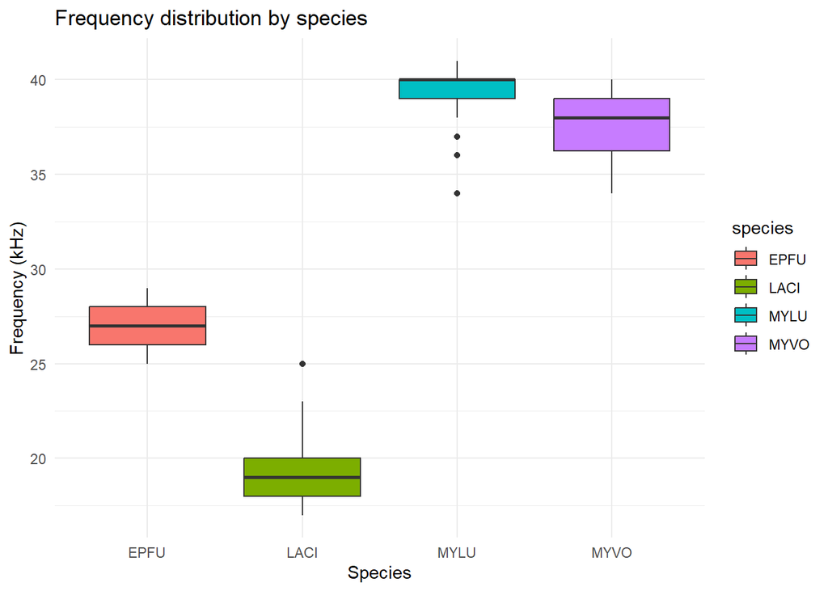

```r
###boxplot of frequency across species
bat_data %>%
  ggplot(aes(x = species, y = frequency, fill =species)) +
  geom_boxplot() +
  labs(
    title = "Frequency distribution by species",
    x = "Species",
    y= "Frequency (kHz)"
  ) +
  theme_minimal()
```

### **Scatterplot: Frequency vs Duration (colored by species)**

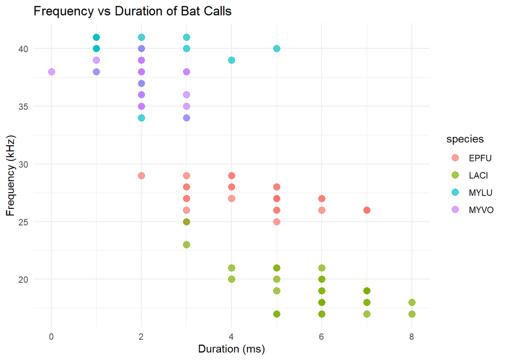

```r
##scaterplot explorng relationship betwen duration and frequency
bat_data %>%
  ggplot(aes(x = duration, y = frequency, color = species)) +
  geom_point(size = 3, alpha = 0.7) +
  labs(
    title = "Frequency vs Duration of Bat Calls",##plot title
    x = "Duration (ms)",
    y = "Frequency (kHz)"
  ) +
  theme_minimal()
```

**Discussion**

This scatter plot demonstrates that every species of bat possesses its own distinctive (vocal) range that is determined by the highness or the elevation (frequency) and the length (duration) of calls. LACI implements extremely low-pitched calls, which would be good in open locations as it travels a long distance. MYLU and MYVO have very high, fast calls, which are ideal in the observation of fine details in crowded areas like forests although the sound does not have a wide coverage. EPFU sits in the middle. Their overlap also indicates that the species have evolved to hunt differently or at different locations in the environment to ensure that they do not interfere with the different species vocalizations..

### **Scatterplot: Time Between Calls vs Frequency**

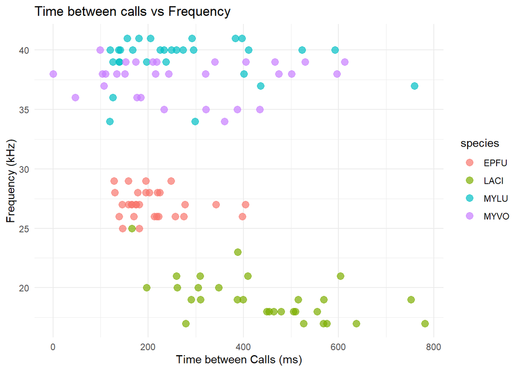

```r
##scaterplot showing time between calls and frequency
bat_data %>%
  ggplot(aes(x = time_btw_calls, y = frequency, color = species)) +
  geom_point(size = 3, alpha = 0.7) +
  labs(
    title = "Time between calls vs Frequency",
    x = "Time between Calls (ms)",
    y = "Frequency (kHz)"
  ) +
  theme_minimal()
```

**Discussion/interpretation**

This scatter plot informs us that every bat talks at a fixed pitch (frequency) but the rate at which it can talk (time between calls) can be varied and varies depending upon what the bat is doing. The pause between their calls can be varied within a large range by all the species, although on a different frequency. This is an important thing about hunting. As an example, a bat calling a long distance will call at a very slow pace whereas as it approaches its prey the chattering will increase at a very high rate to stay updated with its location. This finding indicates that the four species are equally efficient in balancing their echolocator to navigate and preys as required.

### **Density Plot: Frequency Distribution for All Species**

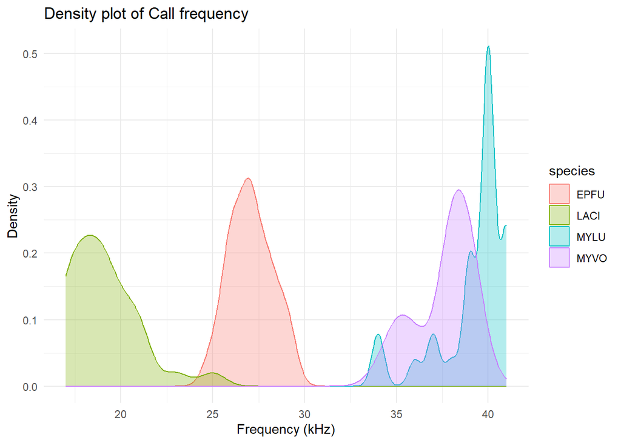

```r
###densityplot showng frequency distributionss of the species
bat_data %>%
  ggplot(aes(x = frequency, color = species, fill = species)) +
  geom_density(alpha = 0.3) +
  labs(
    title = "Density plot of Call frequency",
    x = "Frequency (kHz)",
    y = "Density"
  ) +
  theme_minimal()
```

## **Simple classification model**

### **Multiclass logistic regression model**

In order to further analyze this we construct a multiclass logistic regression model which predicts bat species based on echolocation call parameters. This gives information on the most effective characteristics of calls that distinguish species.

**Load package and split data for training and testing**

```r
##Load needed package
#for multinomial logistic regression
library(nnet)

#split data into training and testing sets
set.seed(123)  # ensures results are reproducible

#create a training index (70% train, 30% test)
train_index <- sample(1:nrow(bat_data), size = 0.7 * nrow(bat_data))

##Split into training and test sets
train_data <- bat_data[train_index, ]
test_data  <- bat_data[-train_index, ]
```

**Fit the model wuth all the four numeric parameters**

```r
##fit multinomial logistic regression
model <- multinom(
  species ~ duration + frequency + time_btw_calls + slope,
  data = train_data
)
#view model summary
summary(model)
```

```
Call:
multinom(formula = species ~ duration + frequency + time_btw_calls +
    slope, data = train_data)

Coefficients:
     (Intercept)   duration frequency time_btw_calls      slope
LACI    110.7771  -6.192466 -2.748380    0.030259836 -0.8527483
MYLU   -114.5860 -11.462333  4.898844    0.009345270 -0.2759618
MYVO   -106.1841 -10.606943  4.502630    0.008006015 -0.2051634

Std. Errors:
     (Intercept)  duration frequency time_btw_calls    slope
LACI  0.08029702 0.1774123  2.178776      0.3965760 2.280517
MYLU  0.09530944 0.4579032  3.105263      0.2575087 1.892091
MYVO  0.10082715 0.4584642  3.104908      0.2575011 1.891962

Residual Deviance: 41.01872
AIC: 71.01872
```

**Make predictions on test set**

```r
#predict species for test data
predicted_species <- predict(model, newdata = test_data)

#compare predicted vs actual species
predicted_species
```

```
 [1] EPFU EPFU EPFU EPFU EPFU EPFU EPFU EPFU EPFU EPFU EPFU EPFU LACI LACI LACI
[16] LACI LACI LACI LACI MYLU MYLU MYLU MYLU MYLU MYLU MYLU MYLU MYVO MYVO MYVO
[31] MYVO MYLU MYVO MYVO MYVO EPFU
Levels: EPFU LACI MYLU MYVO
```

**Calculate model accuracy**

```r
## model accuracy

# Calculate accuracy
accuracy <- mean(predicted_species == test_data$species)
accuracy
```

```
[1] 0.8888889
```

**Confusion matrix**

```r
# Confusion matrix
table(
  Actual = test_data$species,
  Predicted = predicted_species
)
```

```
      Predicted
Actual EPFU LACI MYLU MYVO
  EPFU   11    0    0    0
  LACI    1    7    0    0
  MYLU    0    0    8    1
  MYVO    1    0    1    6
```

#### **Model Results**

**Model Fit**

- **Residual Deviance:** 41.02
- **AIC**: 71.02

These values indicate a reasonably good model fit given the dataset size.

**Coefficients**

Each species (LACI, MYLU, MYVO) has its own set of coefficients comparing it to the baseline category (EPFU). For example:

- **duration** negatively correlates with species, and this indicates that longer call durations reduce the probability to be classified as LACI, MYLU, or MYVO compared to EPFU.
- **frequency** has positive coefficients with MYLU and MYVO and also negative with LACI indicating that frequency assists in distinguishing between species.

**Model prediction accuracy**

Accuracy: **0.8889 (~88.9%)**

This demonstrates good predictive ability of a simple classifier.

**Confusion matrix**

There is a very accurate classification of EPFU (11/11).

LACI is also good with only a single classification.

MYLU and MYVO have slight overlapping, as it is natural because the species tend to share a similar acoustic profile.

## **Conclusion**

In this project, we had to explore a data set of bat echolocation calls with an intention to learn more about species-level acoustic variations and develop a simple predictive model. With data cleaning, descriptive analysis visualizations and classification modeling, some significant findings were determined.

The multinomial logistic regression model was applied as a simple and understandable method of species prediction. Even though it is simple, the model had an accuracy of about 88.9% indicating a good predictability of this such small dataset.

Thanks to the project in general, it was possible to demonstrate that acoustic variables could distinguish among bat species as well as that statistical modeling could facilitate automated species identification. As more data is available, more advanced models can be improved further. Nevertheless, the existing workflow can serve to establish an effective and complete base to be used in future studies of acoustic classification of bat echolocation.